# DSA406 - Project Part 2

Author

Khushi Chaturvedi

Published

April 20, 2026

# 1. Exploratory Data Analysis (EDA) Part 2

Exploratory Data Analysis (EDA) is the first step in data analysis. It is all about learning about the data set’s structure, quality, and first insights before moving on to formal modeling. In Part 2 of this project, we use advanced EDA methods to learn more about the data set than what was asked in the first research question. This is an important step in evaluating data.

The process involves:

- **Analyzing the data distribution** of key variables to identify assumptions, detect outliers and skewness.
- **Using descriptive statistics** (mean, median, standard deviation, and IQR) to quantify and interpret the magnitude and spread of the variables.
- **Investigating the relationships between variables** through correlation analysis to measure the strength of linear association and inform the potential use of a linear model.

# 2. Research Question (Part 1)

**Data set:** YouTube-BoundingBoxes (YT-BB) Detection Data set

**Research Question:** What are the most commonly annotated object classes in the YT-BB data set, and how do bounding box dimensions vary across classes?

**Hypothesis from Part 1:** Different object classes will show distinctly different distributions of bounding box dimensions (width, height, and area), reflecting the natural variation in object sizes in video footage.

**New Hypothesis for Part 2:** Bounding box width and height will be positively correlated, meaning objects that are wider in the frame will also tend to be taller suggesting that bounding box area can be reasonably predicted using a linear combination of width and height.

**What do we expect to find?** We think that the width and height of the bounding box will have a moderate-to-strong positive linear relationship because most physical objects have dimensions that are proportional to each other. We also think that the distributions of bounding box sizes will be right-skewed because most of the objects we find in a video frame are small, with only a few very large ones.

**Which individuals or groups does the data relate to?** The data relates to video frames from YouTube videos, specifically the bounding box annotations for 23 different object classes (e.g., person, car, cat) across 100,000 rows of annotation data.

# 3. Data Set Overview

**Data set name:** YouTube-BoundingBoxes (YT-BB) Detection Training Set

```r
library(knitr)
library(kableExtra)

# Dataset properties table
dataset_info <- data.frame(
  Property = c("Total Rows Loaded", "Total Columns", "Source"),
  Value    = c("100,000", "10", "YouTube-BoundingBoxes (Google Research)")
)

kable(dataset_info, align = c("l", "l"),
      caption = "Dataset Properties") %>%
  kable_styling(bootstrap_options = c("striped", "hover", "bordered"),
                full_width = FALSE)
```

Dataset Properties

| Property | Value |
| --- | --- |
| Total Rows Loaded | 100,000 |
| Total Columns | 10 |
| Source | YouTube-BoundingBoxes (Google Research) |

**Variables of Interest (for Core Analysis)**

```r
# Variables of interest table
variables_info <- data.frame(
  Variable = c("`class_name`", "`object_presence`", "`xmin`, `xmax`",
               "`ymin`, `ymax`", "`bb_width`", "`bb_height`", "`bb_area`"),
  Type = c("Categorical (Factor)", "Categorical (Factor)",
           "Numeric (continuous)", "Numeric (continuous)",
           "Numeric (derived)", "Numeric (derived)", "Numeric (derived)"),
  Description = c(
    'Object category label (e.g., "person", "cat")',
    "Whether the object is present or absent",
    "Horizontal bounding box edges (normalized 0-1)",
    "Vertical bounding box edges (normalized 0-1)",
    "Bounding box width = xmax - xmin",
    "Bounding box height = ymax - ymin",
    "Bounding box area = bb_width x bb_height"
  )
)

kable(variables_info, align = c("l", "l", "l"),
      caption = "Variables of Interest") %>%
  kable_styling(bootstrap_options = c("striped", "hover", "bordered"),
                full_width = TRUE) %>%
  column_spec(1, bold = TRUE)
```

Variables of Interest

| Variable | Type | Description |
| --- | --- | --- |
| `class_name` | Categorical (Factor) | Object category label (e.g., "person", "cat") |
| `object_presence` | Categorical (Factor) | Whether the object is present or absent |
| `xmin`, `xmax` | Numeric (continuous) | Horizontal bounding box edges (normalized 0-1) |
| `ymin`, `ymax` | Numeric (continuous) | Vertical bounding box edges (normalized 0-1) |
| `bb_width` | Numeric (derived) | Bounding box width = xmax - xmin |
| `bb_height` | Numeric (derived) | Bounding box height = ymax - ymin |
| `bb_area` | Numeric (derived) | Bounding box area = bb_width x bb_height |

**Levels of categorical variables:**

- `object_presence`: 2 levels — *present*, *absent*
- `class_name`: 23 levels — including *person*, *car*, *cat*, *dog*, *bird*, and others.

**Units of quantitative variables:**

- All bounding box coordinate and dimension variables are measured in **normalized units (0 to 1)**, where 1.0 represents the full width or height of the video frame.

# 4. Running Code

## 4.1 Uploading and Reading the Data Set

Before beginning the analysis, all necessary packages are loaded. The data set is read into R and the column names are defined manually since the raw CSV file does not contain a header row.

```r
# Load core packages for data manipulation, visualization, and reporting
library(tidyverse)
library(ggplot2)
library(dplyr)
library(readr)
library(rmarkdown)
library(janitor)

# Read the YT-BB CSV file; column names are defined manually since the file has no header
df <- read_csv(
  "youtube_boundingboxes_detection_train.csv",
  col_names = c("youtube_id", "timestamp_ms", "class_id",
                "class_name", "object_id", "object_presence",
                "xmin", "xmax", "ymin", "ymax"),
  n_max = 100000
)

# clean_names() from janitor standardizes column names to snake_case
df <- df %>% clean_names()

# Preview the first 6 rows as a formatted table
kable(head(df), caption = "First 6 Rows of the YT-BB Dataset") %>%
  kable_styling(bootstrap_options = c("striped", "hover", "bordered"),
                full_width = TRUE,
                font_size  = 12) %>%
  scroll_box(width = "100%")
```

First 6 Rows of the YT-BB Dataset

| youtube_id | timestamp_ms | class_id | class_name | object_id | object_presence | xmin | xmax | ymin | ymax |
| --- | --- | --- | --- | --- | --- | --- | --- | --- | --- |
| AAB6lO-XiKE | 238000 | 0 | person | 0 | present | 0.482 | 0.540 | 0.3716667 | 0.6166667 |
| AAB6lO-XiKE | 239000 | 0 | person | 0 | present | 0.514 | 0.588 | 0.3633333 | 0.6066667 |
| AAB6lO-XiKE | 240000 | 0 | person | 0 | present | 0.534 | 0.614 | 0.4433333 | 0.6850000 |
| AAB6lO-XiKE | 241000 | 0 | person | 0 | present | 0.515 | 0.605 | 0.4483333 | 0.6866667 |
| AAB6lO-XiKE | 242000 | 0 | person | 0 | present | 0.550 | 0.600 | 0.4000000 | 0.6383333 |
| AAB6lO-XiKE | 243000 | 0 | person | 0 | present | 0.539 | 0.607 | 0.3600000 | 0.6066667 |

## 4.2 Data Cleaning: Removing Missing Values and Preparing Variables

This step ensures we are working with a clean data set by removing any incomplete rows. We also convert categorical variables to factors and compute new derived variables (bounding box width, height, and area) that are central to our Part 2 analysis.

```r
# Identify and keep only complete rows (no missing values)
rowscomplete <- complete.cases(df)
df <- df[rowscomplete, ]

# Convert categorical variables to factor type for proper handling in R
df <- df %>%
  mutate(across(c(class_name, object_presence), as.factor))

# Filter to only rows where the object is present in the frame
df_present <- df %>%
  filter(object_presence == "present")

# Create derived bounding box dimension variables
df_present <- df_present %>%
  mutate(
    bb_width  = xmax - xmin,
    bb_height = ymax - ymin,
    bb_area   = bb_width * bb_height
  )

# Preview the cleaned and enriched dataset
paged_table(df_present)
```

| youtube_id | timestamp_ms | class_id | class_name | object_id | object_presence | xmin | xmax | ymin | ymax | bb_width | bb_height | bb_area |
| --- | --- | --- | --- | --- | --- | --- | --- | --- | --- | --- | --- | --- |
| AAB6lO-XiKE | 238000 | 0 | person | 0 | present | 0.482 | 0.540 | 0.371666670 | 0.61666670 | 0.058 | 0.245000030 | 0.0142100017 |
| AAB6lO-XiKE | 239000 | 0 | person | 0 | present | 0.514 | 0.588 | 0.363333340 | 0.60666670 | 0.074 | 0.243333360 | 0.0180066686 |
| AAB6lO-XiKE | 240000 | 0 | person | 0 | present | 0.534 | 0.614 | 0.443333330 | 0.68500000 | 0.080 | 0.241666670 | 0.0193333336 |
| AAB6lO-XiKE | 241000 | 0 | person | 0 | present | 0.515 | 0.605 | 0.448333320 | 0.68666667 | 0.090 | 0.238333350 | 0.0214500015 |
| AAB6lO-XiKE | 242000 | 0 | person | 0 | present | 0.550 | 0.600 | 0.400000000 | 0.63833330 | 0.050 | 0.238333300 | 0.0119166650 |
| AAB6lO-XiKE | 243000 | 0 | person | 0 | present | 0.539 | 0.607 | 0.360000000 | 0.60666670 | 0.068 | 0.246666700 | 0.0167733356 |
| AAB6lO-XiKE | 244000 | 0 | person | 0 | present | 0.550 | 0.593 | 0.355000000 | 0.59500000 | 0.043 | 0.240000000 | 0.0103200000 |
| AAB6lO-XiKE | 245000 | 0 | person | 0 | present | 0.584 | 0.627 | 0.331666680 | 0.57833330 | 0.043 | 0.246666620 | 0.0106066647 |
| AAB6lO-XiKE | 246000 | 0 | person | 0 | present | 0.618 | 0.659 | 0.251666670 | 0.49166667 | 0.041 | 0.240000000 | 0.0098400000 |
| AAB6lO-XiKE | 247000 | 0 | person | 0 | present | 0.643 | 0.689 | 0.228333340 | 0.47500000 | 0.046 | 0.246666660 | 0.0113466664 |

[output cut: 9990 more lines]

# 5. Describing Data

In this section, we compute key descriptive statistics to gain a comprehensive understanding of the data set’s structure, central tendency, and spread. We focus on bounding box dimensions (`bb_width`, `bb_height`, `bb_area`) because they are the primary quantitative variables of interest. These summaries are crucial for detecting unusual values and outliers, and for verifying distribution assumptions necessary for correlation and linear modeling.

```r
# Load psych package for rich descriptive statistics
library(psych)

# Select only the key numeric variables for the descriptive analysis
df_numeric <- df_present %>%
  select(xmin, xmax, ymin, ymax, bb_width, bb_height, bb_area)

# Generate descriptive statistics and display as a formatted table
desc_table <- describe(df_numeric)

kable(round(desc_table, 3),
      caption = "Descriptive Statistics for Key Numeric Variables") %>%
  kable_styling(bootstrap_options = c("striped", "hover", "bordered"),
                full_width = TRUE,
                font_size = 13) %>%
  row_spec(5:7, background = "#f0f7ff") %>%
  scroll_box(width = "100%")
```

Descriptive Statistics for Key Numeric Variables

|  | vars | n | mean | sd | median | trimmed | mad | min | max | range | skew | kurtosis | se |
| --- | --- | --- | --- | --- | --- | --- | --- | --- | --- | --- | --- | --- | --- |
| xmin | 1 | 80459 | 0.267 | 0.224 | 0.246 | 0.246 | 0.271 | 0.000 | 0.992 | 0.992 | 0.585 | -0.374 | 0.001 |
| xmax | 2 | 80459 | 0.742 | 0.224 | 0.768 | 0.764 | 0.277 | 0.008 | 1.000 | 0.992 | -0.632 | -0.315 | 0.001 |
| ymin | 3 | 80459 | 0.242 | 0.206 | 0.220 | 0.221 | 0.242 | 0.000 | 0.982 | 0.982 | 0.657 | -0.187 | 0.001 |
| ymax | 4 | 80459 | 0.825 | 0.183 | 0.865 | 0.849 | 0.200 | 0.000 | 1.000 | 1.000 | -0.910 | 0.243 | 0.001 |
| bb_width | 5 | 80459 | 0.475 | 0.294 | 0.428 | 0.460 | 0.348 | 0.007 | 1.000 | 0.993 | 0.362 | -1.074 | 0.001 |
| bb_height | 6 | 80459 | 0.583 | 0.283 | 0.578 | 0.588 | 0.358 | 0.000 | 1.000 | 1.000 | -0.056 | -1.155 | 0.001 |
| bb_area | 7 | 80459 | 0.323 | 0.283 | 0.239 | 0.288 | 0.264 | 0.000 | 1.000 | 1.000 | 0.889 | -0.246 | 0.001 |

## 5.1 `describeBy()` — Descriptive Statistics Grouped by Object Class

The `describeBy()` function produces the same statistics separately for each group. Here we compute statistics for bounding box dimensions grouped by the top 5 most common object classes.

```r
# Compute the top 5 most frequent object classes
class_counts <- df_present %>%
  count(class_name, sort = TRUE)

top5_classes <- class_counts %>%
  slice_head(n = 5) %>%
  pull(class_name)

# Subset to top 5 classes
df_top5 <- df_present %>%
  filter(class_name %in% top5_classes) %>%
  select(class_name, bb_width, bb_height, bb_area)

# Run grouped descriptive statistics
desc_by <- describeBy(
  df_top5[, c("bb_width", "bb_height", "bb_area")],
  group = df_top5$class_name,
  mat   = TRUE
)

# Build clean table rounding each numeric column individually
desc_by_clean <- data.frame(
  Class    = desc_by$group1,
  N        = desc_by$n,
  Mean     = round(desc_by$mean, 3),
  SD       = round(desc_by$sd, 3),
  Median   = round(desc_by$median, 3),
  Min      = round(desc_by$min, 3),
  Max      = round(desc_by$max, 3),
  Skew     = round(desc_by$skew, 3),
  Kurtosis = round(desc_by$kurtosis, 3)
)

kable(desc_by_clean,
      caption   = "Descriptive Statistics by Top 5 Object Classes",
      row.names = FALSE) %>%
  kable_styling(bootstrap_options = c("striped", "hover", "bordered"),
                full_width = TRUE,
                font_size  = 13) %>%
  column_spec(1, bold = TRUE)
```

Descriptive Statistics by Top 5 Object Classes

| Class | N | Mean | SD | Median | Min | Max | Skew | Kurtosis |
| --- | --- | --- | --- | --- | --- | --- | --- | --- |
| airplane | 3884 | 0.762 | 0.238 | 0.825 | 0.009 | 1 | -0.788 | -0.306 |
| bear | NA | NA | NA | NA | NA | NA | NA | NA |
| bicycle | NA | NA | NA | NA | NA | NA | NA | NA |
| bird | NA | NA | NA | NA | NA | NA | NA | NA |
| boat | NA | NA | NA | NA | NA | NA | NA | NA |
| bus | NA | NA | NA | NA | NA | NA | NA | NA |
| car | NA | NA | NA | NA | NA | NA | NA | NA |
| cat | 3716 | 0.608 | 0.234 | 0.599 | 0.017 | 1 | 0.025 | -0.942 |
| cow | NA | NA | NA | NA | NA | NA | NA | NA |
| dog | NA | NA | NA | NA | NA | NA | NA | NA |
| elephant | NA | NA | NA | NA | NA | NA | NA | NA |
| giraffe | NA | NA | NA | NA | NA | NA | NA | NA |
| horse | 4557 | 0.367 | 0.200 | 0.348 | 0.010 | 1 | 0.595 | 0.084 |
| knife | NA | NA | NA | NA | NA | NA | NA | NA |
| motorcycle | NA | NA | NA | NA | NA | NA | NA | NA |
| person | 18973 | 0.328 | 0.247 | 0.249 | 0.007 | 1 | 1.084 | 0.378 |
| potted plant | NA | NA | NA | NA | NA | NA | NA | NA |
| skateboard | NA | NA | NA | NA | NA | NA | NA | NA |
| toilet | NA | NA | NA | NA | NA | NA | NA | NA |
| train | 4058 | 0.692 | 0.302 | 0.785 | 0.008 | 1 | -0.671 | -0.861 |
| truck | NA | NA | NA | NA | NA | NA | NA | NA |
| umbrella | NA | NA | NA | NA | NA | NA | NA | NA |
| zebra | NA | NA | NA | NA | NA | NA | NA | NA |
| airplane | 3884 | 0.548 | 0.275 | 0.483 | 0.015 | 1 | 0.270 | -1.144 |
| bear | NA | NA | NA | NA | NA | NA | NA | NA |
| bicycle | NA | NA | NA | NA | NA | NA | NA | NA |
| bird | NA | NA | NA | NA | NA | NA | NA | NA |
| boat | NA | NA | NA | NA | NA | NA | NA | NA |
| bus | NA | NA | NA | NA | NA | NA | NA | NA |
| car | NA | NA | NA | NA | NA | NA | NA | NA |
| cat | 3716 | 0.695 | 0.223 | 0.711 | 0.058 | 1 | -0.342 | -0.759 |
| cow | NA | NA | NA | NA | NA | NA | NA | NA |
| dog | NA | NA | NA | NA | NA | NA | NA | NA |
| elephant | NA | NA | NA | NA | NA | NA | NA | NA |
| giraffe | NA | NA | NA | NA | NA | NA | NA | NA |
| horse | 4557 | 0.498 | 0.210 | 0.493 | 0.023 | 1 | 0.257 | -0.365 |
| knife | NA | NA | NA | NA | NA | NA | NA | NA |
| motorcycle | NA | NA | NA | NA | NA | NA | NA | NA |
| person | 18973 | 0.623 | 0.277 | 0.645 | 0.000 | 1 | -0.264 | -1.122 |
| potted plant | NA | NA | NA | NA | NA | NA | NA | NA |
| skateboard | NA | NA | NA | NA | NA | NA | NA | NA |
| toilet | NA | NA | NA | NA | NA | NA | NA | NA |
| train | 4058 | 0.641 | 0.322 | 0.688 | 0.017 | 1 | -0.296 | -1.392 |
| truck | NA | NA | NA | NA | NA | NA | NA | NA |
| umbrella | NA | NA | NA | NA | NA | NA | NA | NA |
| zebra | NA | NA | NA | NA | NA | NA | NA | NA |
| airplane | 3884 | 0.463 | 0.305 | 0.391 | 0.000 | 1 | 0.398 | -1.095 |
| bear | NA | NA | NA | NA | NA | NA | NA | NA |
| bicycle | NA | NA | NA | NA | NA | NA | NA | NA |
| bird | NA | NA | NA | NA | NA | NA | NA | NA |
| boat | NA | NA | NA | NA | NA | NA | NA | NA |
| bus | NA | NA | NA | NA | NA | NA | NA | NA |
| car | NA | NA | NA | NA | NA | NA | NA | NA |
| cat | 3716 | 0.453 | 0.265 | 0.403 | 0.001 | 1 | 0.443 | -0.839 |
| cow | NA | NA | NA | NA | NA | NA | NA | NA |
| dog | NA | NA | NA | NA | NA | NA | NA | NA |
| elephant | NA | NA | NA | NA | NA | NA | NA | NA |
| giraffe | NA | NA | NA | NA | NA | NA | NA | NA |
| horse | 4557 | 0.209 | 0.173 | 0.174 | 0.000 | 1 | 1.451 | 2.654 |
| knife | NA | NA | NA | NA | NA | NA | NA | NA |
| motorcycle | NA | NA | NA | NA | NA | NA | NA | NA |
| person | 18973 | 0.248 | 0.243 | 0.165 | 0.000 | 1 | 1.240 | 0.835 |
| potted plant | NA | NA | NA | NA | NA | NA | NA | NA |
| skateboard | NA | NA | NA | NA | NA | NA | NA | NA |
| toilet | NA | NA | NA | NA | NA | NA | NA | NA |
| train | 4058 | 0.490 | 0.329 | 0.463 | 0.000 | 1 | 0.126 | -1.339 |
| truck | NA | NA | NA | NA | NA | NA | NA | NA |
| umbrella | NA | NA | NA | NA | NA | NA | NA | NA |
| zebra | NA | NA | NA | NA | NA | NA | NA | NA |

**Interpretation:** The grouped statistics reveal meaningful differences across object classes. Person annotations tend to have taller bounding boxes relative to width, reflecting the upright human form. High standard deviation values within classes indicate considerable variation in object size, reflecting objects appearing at different distances from the camera.

# 6. Data Distribution and Why It Matters

Understanding the data distribution of our key variables allows us to verify normality assumptions required by correlation and linear models, detect skewness and outliers, and identify unusual patterns not evaluated in Part 1. A variable is considered approximately normal if its skewness is between -1 and +1.

## 6.1 skim() Function from the skimr Package

```r
# Load skimr package
library(skimr)

# Apply skim() to the key numeric variables
skim(df_numeric)
```

Data summary

| Name | df_numeric |
| --- | --- |
| Number of rows | 80459 |
| Number of columns | 7 |
| _______________________ |  |
| Column type frequency: |  |
| numeric | 7 |
| ________________________ |  |
| Group variables | None |

**Variable type: numeric**

| skim_variable | n_missing | complete_rate | mean | sd | p0 | p25 | p50 | p75 | p100 | hist |
| --- | --- | --- | --- | --- | --- | --- | --- | --- | --- | --- |
| xmin | 0 | 1 | 0.27 | 0.22 | 0.00 | 0.06 | 0.25 | 0.42 | 0.99 | ▇▆▃▁▁ |
| xmax | 0 | 1 | 0.74 | 0.22 | 0.01 | 0.59 | 0.77 | 0.96 | 1.00 | ▁▁▃▅▇ |
| ymin | 0 | 1 | 0.24 | 0.21 | 0.00 | 0.05 | 0.22 | 0.38 | 0.98 | ▇▅▃▁▁ |
| ymax | 0 | 1 | 0.82 | 0.18 | 0.00 | 0.70 | 0.86 | 1.00 | 1.00 | ▁▁▂▃▇ |
| bb_width | 0 | 1 | 0.48 | 0.29 | 0.01 | 0.22 | 0.43 | 0.71 | 1.00 | ▇▇▆▅▆ |
| bb_height | 0 | 1 | 0.58 | 0.28 | 0.00 | 0.35 | 0.58 | 0.83 | 1.00 | ▃▆▆▆▇ |
| bb_area | 0 | 1 | 0.32 | 0.28 | 0.00 | 0.09 | 0.24 | 0.49 | 1.00 | ▇▅▂▂▂ |

## 6.2 dfSummary() Function from the summarytools Package

```r
library(summarytools)

st_options(plain.ascii      = FALSE,
           style            = "grid",
           dfSummary.silent = TRUE,
           footnote         = NA)

# graph.col = FALSE hides the built-in gray graphs
# so we rely on the colorful ggplot panel below instead
print(
  dfSummary(df_numeric,
            graph.col    = FALSE,
            graph.magnif = 0.75,
            valid.col    = FALSE),
  method = "render"
)
```

Data Frame Summary

df_numeric

**Dimensions**: 80459 x 7  
**Duplicates**: 6744

| **No** | **Variable** | **Stats / Values** | **Freqs (% of Valid)** | **Missing** |
| --- | --- | --- | --- | --- |
| 1 | xmin [numeric] | Mean (sd) : 0.3 (0.2) min ≤ med ≤ max: 0 ≤ 0.2 ≤ 1 IQR (CV) : 0.4 (0.8) | 996 distinct values | 0 (0.0%) |
| 2 | xmax [numeric] | Mean (sd) : 0.7 (0.2) min ≤ med ≤ max: 0 ≤ 0.8 ≤ 1 IQR (CV) : 0.4 (0.3) | 1005 distinct values | 0 (0.0%) |
| 3 | ymin [numeric] | Mean (sd) : 0.2 (0.2) min ≤ med ≤ max: 0 ≤ 0.2 ≤ 1 IQR (CV) : 0.3 (0.9) | 588 distinct values | 0 (0.0%) |
| 4 | ymax [numeric] | Mean (sd) : 0.8 (0.2) min ≤ med ≤ max: 0 ≤ 0.9 ≤ 1 IQR (CV) : 0.3 (0.2) | 588 distinct values | 0 (0.0%) |
| 5 | bb_width [numeric] | Mean (sd) : 0.5 (0.3) min ≤ med ≤ max: 0 ≤ 0.4 ≤ 1 IQR (CV) : 0.5 (0.6) | 1111 distinct values | 0 (0.0%) |
| 6 | bb_height [numeric] | Mean (sd) : 0.6 (0.3) min ≤ med ≤ max: 0 ≤ 0.6 ≤ 1 IQR (CV) : 0.5 (0.5) | 7579 distinct values | 0 (0.0%) |
| 7 | bb_area [numeric] | Mean (sd) : 0.3 (0.3) min ≤ med ≤ max: 0 ≤ 0.2 ≤ 1 IQR (CV) : 0.4 (0.9) | 66759 distinct values | 0 (0.0%) |

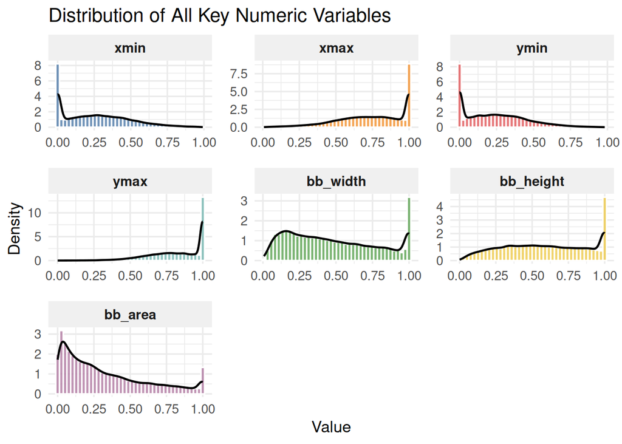

Distribution panel for all key numeric variables. Each facet shows a histogram with a density curve, colored individually to make comparison easy across variables.

```r
var_colors <- c(
  "xmin"      = "#4E79A7",
  "xmax"      = "#F28E2B",
  "ymin"      = "#E15759",
  "ymax"      = "#76B7B2",
  "bb_width"  = "#59A14F",
  "bb_height" = "#EDC948",
  "bb_area"   = "#B07AA1"
)

df_long <- df_numeric %>%
  pivot_longer(cols = everything(),
               names_to  = "variable",
               values_to = "value")

df_long$variable <- factor(df_long$variable,
                            levels = names(var_colors))

ggplot(df_long, aes(x = value, fill = variable)) +
  geom_histogram(aes(y = after_stat(density)),
                 bins  = 40,
                 alpha = 0.8,
                 color = "white") +
  geom_density(linewidth = 0.8, color = "black", alpha = 0) +
  facet_wrap(~ variable, scales = "free", ncol = 3) +
  scale_fill_manual(values = var_colors) +
  labs(title = "Distribution of All Key Numeric Variables",
       x     = "Value",
       y     = "Density") +
  theme_minimal(base_size = 13) +
  theme(
    legend.position  = "none",
    strip.background = element_rect(fill = "#f0f0f0", color = NA),
    strip.text       = element_text(face = "bold", size = 11),
    panel.spacing    = unit(1, "lines")
  )
```

## 6.3 Normality Assessment: Plots

A plot compares the quantiles of our data against a theoretical normal distribution. Points falling along the diagonal line indicate normality. Deviations, especially in the tails, indicate non-normality.

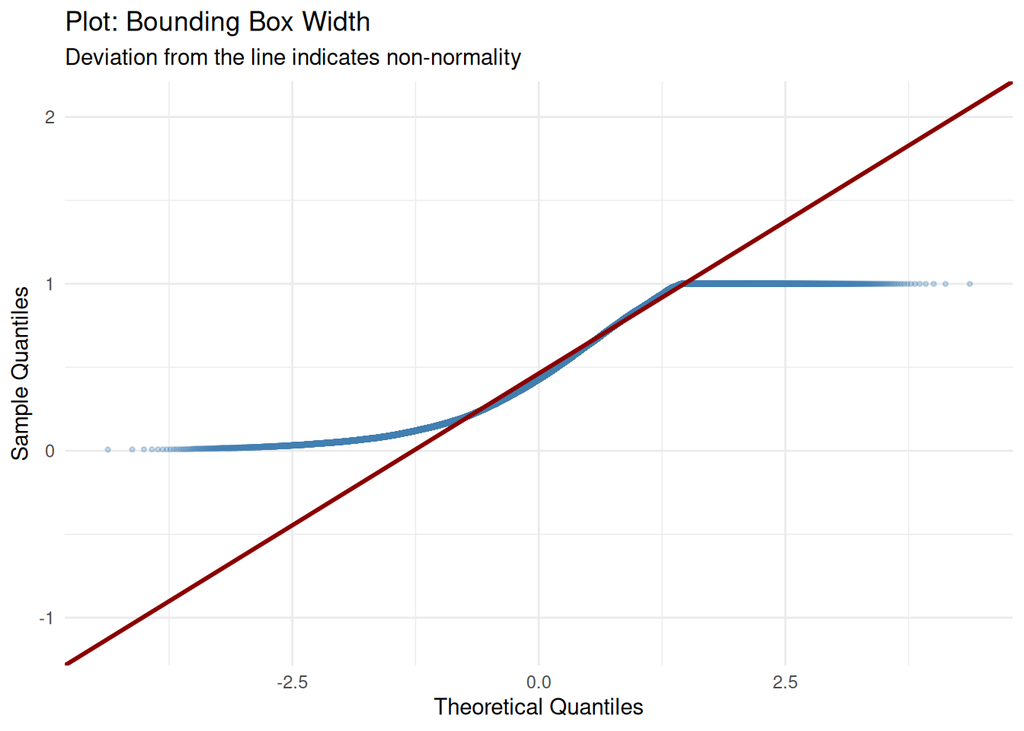

Plot for bb_width: Points deviating from the red line in the tails indicate the variable is right-skewed and not normally distributed.

```r
ggplot(df_present, aes(sample = bb_width)) +
  stat_qq(color = "steelblue", alpha = 0.3, size = 0.8) +
  stat_qq_line(color = "darkred", linewidth = 1) +
  labs(title = "Plot: Bounding Box Width",
       subtitle = "Deviation from the line indicates non-normality",
       x = "Theoretical Quantiles", y = "Sample Quantiles") +
  theme_minimal()
```

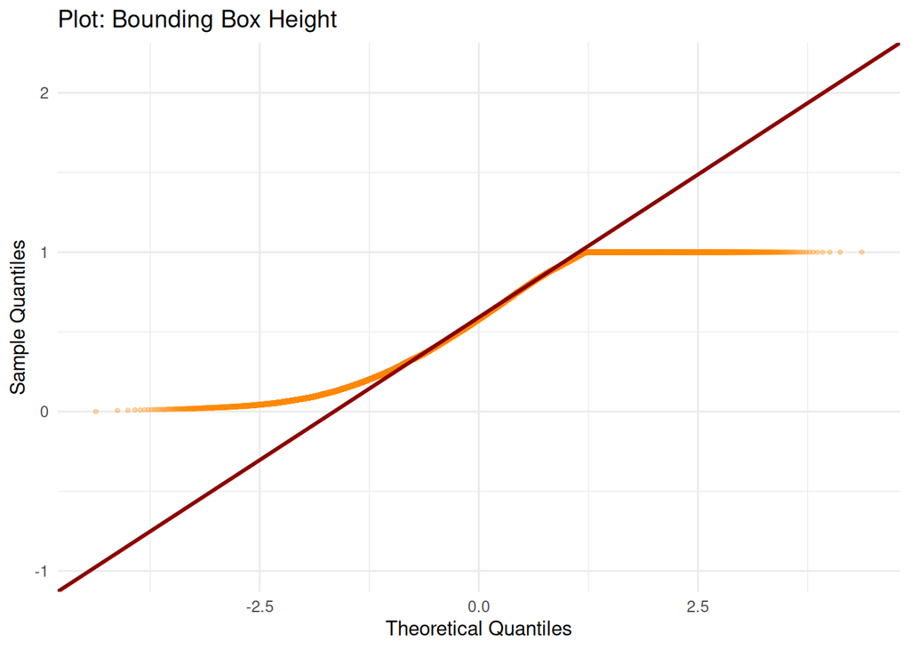

```r
ggplot(df_present, aes(sample = bb_height)) +
  stat_qq(color = "darkorange", alpha = 0.3, size = 0.8) +
  stat_qq_line(color = "darkred", linewidth = 1) +
  labs(title = "Plot: Bounding Box Height",
       x = "Theoretical Quantiles", y = "Sample Quantiles") +
  theme_minimal()
```

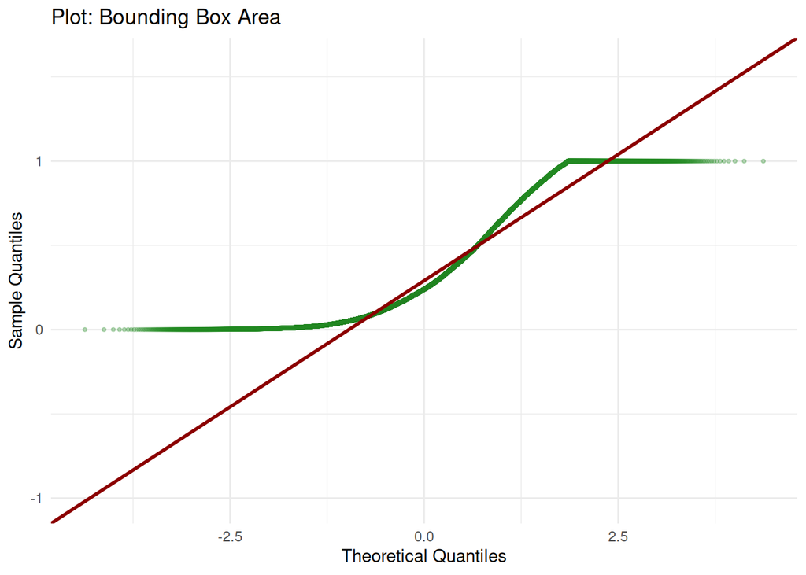

```r
ggplot(df_present, aes(sample = bb_area)) +
  stat_qq(color = "forestgreen", alpha = 0.3, size = 0.8) +
  stat_qq_line(color = "darkred", linewidth = 1) +
  labs(title = "Plot: Bounding Box Area",
       x = "Theoretical Quantiles", y = "Sample Quantiles") +
  theme_minimal()
```

## 6.4 Histograms with Density Curves

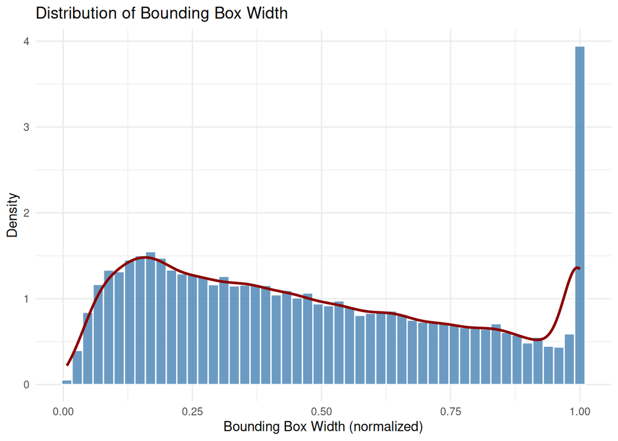

Distribution of bounding box width: The right-skewed shape shows most objects occupy less than half the frame width, with a few very wide detections creating the long tail.

```r
ggplot(df_present, aes(x = bb_width)) +
  geom_histogram(aes(y = after_stat(density)),
                 bins = 50, fill = "steelblue", color = "white", alpha = 0.8) +
  geom_density(color = "darkred", linewidth = 1) +
  labs(title = "Distribution of Bounding Box Width",
       x = "Bounding Box Width (normalized)", y = "Density") +
  theme_minimal()
```

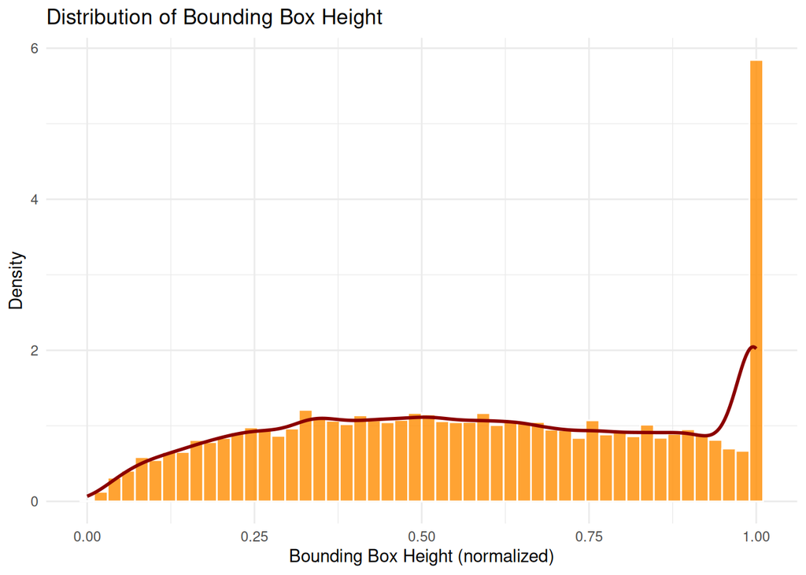

```r
ggplot(df_present, aes(x = bb_height)) +
  geom_histogram(aes(y = after_stat(density)),
                 bins = 50, fill = "darkorange", color = "white", alpha = 0.8) +
  geom_density(color = "darkred", linewidth = 1) +
  labs(title = "Distribution of Bounding Box Height",
       x = "Bounding Box Height (normalized)", y = "Density") +
  theme_minimal()
```

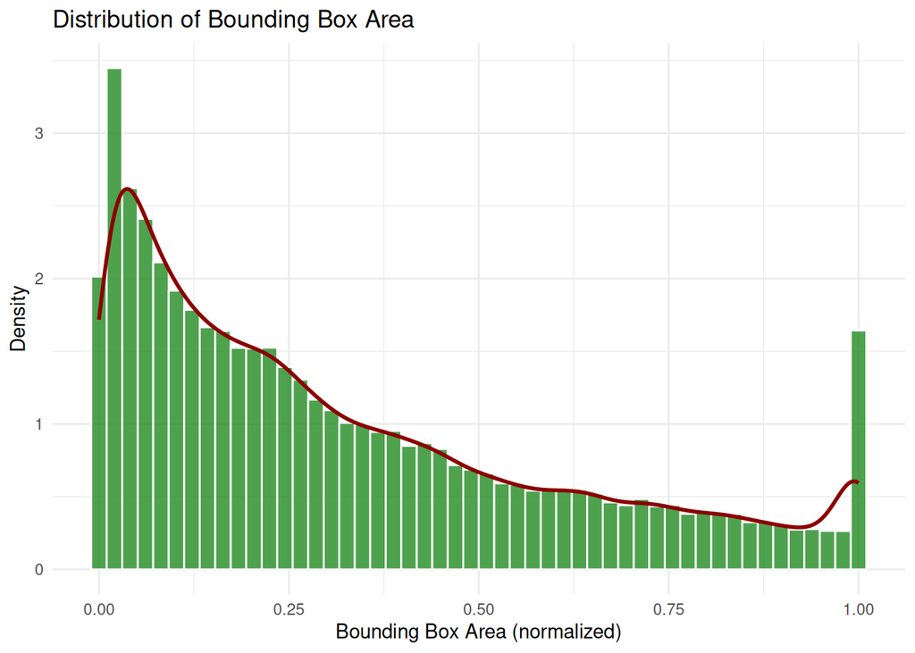

Distribution of bounding box area: The most strongly skewed of the three variables. Most annotated objects are small relative to the total frame area.

```r
ggplot(df_present, aes(x = bb_area)) +
  geom_histogram(aes(y = after_stat(density)),
                 bins = 50, fill = "forestgreen", color = "white", alpha = 0.8) +
  geom_density(color = "darkred", linewidth = 1) +
  labs(title = "Distribution of Bounding Box Area",
       x = "Bounding Box Area (normalized)", y = "Density") +
  theme_minimal()
```

# 7. Normalization

```r
# Apply log transformation (log1p handles zero values safely)
df_present <- df_present %>%
  mutate(
    log_bb_width  = log1p(bb_width),
    log_bb_height = log1p(bb_height),
    log_bb_area   = log1p(bb_area)
  )
```

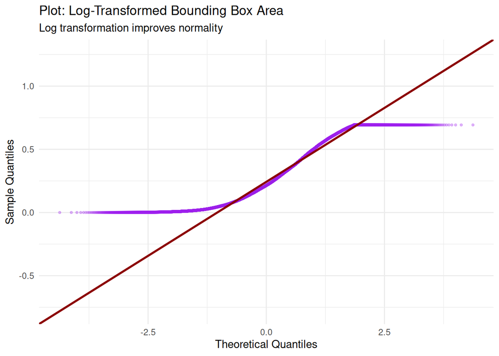

```r
ggplot(df_present, aes(sample = log_bb_area)) +
  stat_qq(color = "purple", alpha = 0.3, size = 0.8) +
  stat_qq_line(color = "darkred", linewidth = 1) +
  labs(title = "Plot: Log-Transformed Bounding Box Area",
       subtitle = "Log transformation improves normality",
       x = "Theoretical Quantiles", y = "Sample Quantiles") +
  theme_minimal()
```

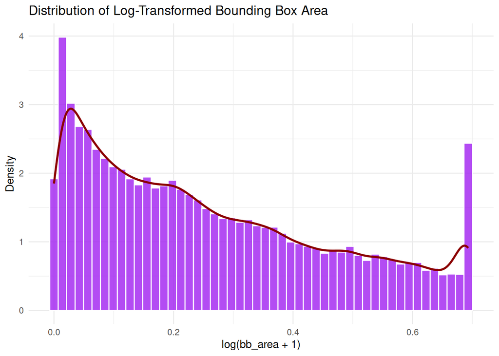

```r
ggplot(df_present, aes(x = log_bb_area)) +
  geom_histogram(aes(y = after_stat(density)),
                 bins = 50, fill = "purple", color = "white", alpha = 0.8) +
  geom_density(color = "darkred", linewidth = 1) +
  labs(title = "Distribution of Log-Transformed Bounding Box Area",
       x = "log(bb_area + 1)", y = "Density") +
  theme_minimal()
```

# 8. Introduction to Relationships

## 8.1 Correlation

Correlation measures the **strength and direction of the linear relationship** between two quantitative variables. The correlation coefficient (r) ranges from -1 to +1, where +1 is a perfect positive relationship, 0 is no relationship, and -1 is a perfect negative relationship.

## 8.3 Scatter Plot: Exploring the Relationship

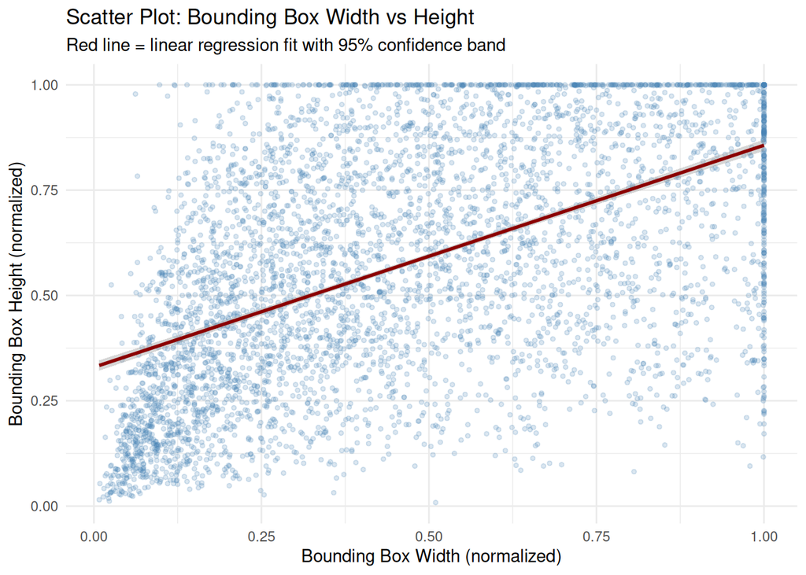

Scatter plot of bounding box width vs height for a random sample of 5,000 annotations. The red line shows the linear regression fit with a 95% confidence band, revealing a moderate positive relationship.

```r
set.seed(42)
df_sample <- df_present %>% slice_sample(n = 5000)

ggplot(df_sample, aes(x = bb_width, y = bb_height)) +
  geom_point(alpha = 0.2, color = "steelblue", size = 1) +
  geom_smooth(method = "lm", color = "darkred", se = TRUE, linewidth = 1) +
  labs(title = "Scatter Plot: Bounding Box Width vs Height",
       subtitle = "Red line = linear regression fit with 95% confidence band",
       x = "Bounding Box Width (normalized)",
       y = "Bounding Box Height (normalized)") +
  theme_minimal()
```

**Interpretation:** The scatter plot reveals a moderate positive linear trend between bounding box width and height. As width increases, height also tends to increase, consistent with our hypothesis. The considerable spread around the regression line indicates the relationship is not deterministic some objects are wide but short (e.g., cars) while others are tall but narrow (e.g., people).

## 8.4 Pearson Correlation Matrix for Numeric Variables

```r
# Select the key numeric variables for correlation
df_corr <- df_present %>%
  select(bb_width, bb_height, bb_area, xmin, xmax, ymin, ymax)

# Compute the Pearson correlation matrix
cor_matrix <- cor(df_corr, use = "complete.obs", method = "pearson")

# Display as a formatted table
kable(round(cor_matrix, 3),
      caption = "Pearson Correlation Matrix — Bounding Box Variables") %>%
  kable_styling(bootstrap_options = c("striped", "hover", "bordered"),
                full_width = FALSE,
                font_size  = 13) %>%
  column_spec(1, bold = TRUE)
```

Pearson Correlation Matrix — Bounding Box Variables

|  | bb_width | bb_height | bb_area | xmin | xmax | ymin | ymax |
| --- | --- | --- | --- | --- | --- | --- | --- |
| bb_width | 1.000 | 0.559 | 0.885 | -0.656 | 0.656 | -0.464 | 0.342 |
| bb_height | 0.559 | 1.000 | 0.800 | -0.353 | 0.380 | -0.765 | 0.687 |
| bb_area | 0.885 | 0.800 | 1.000 | -0.577 | 0.584 | -0.643 | 0.515 |
| xmin | -0.656 | -0.353 | -0.577 | 1.000 | 0.139 | 0.291 | -0.219 |
| xmax | 0.656 | 0.380 | 0.584 | 0.139 | 1.000 | -0.318 | 0.230 |
| ymin | -0.464 | -0.765 | -0.643 | 0.291 | -0.318 | 1.000 | -0.057 |
| ymax | 0.342 | 0.687 | 0.515 | -0.219 | 0.230 | -0.057 | 1.000 |

## 8.5 Correlation Heatmap

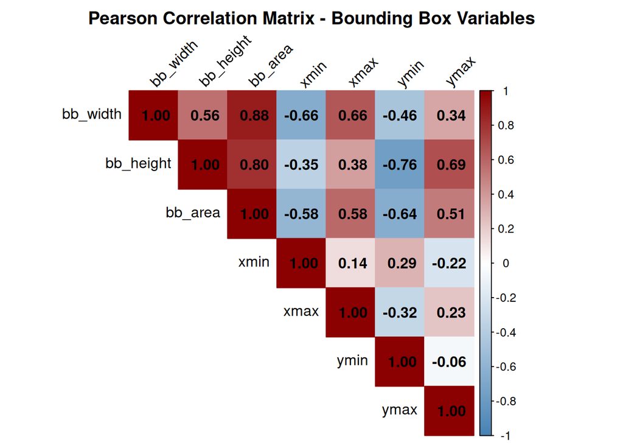

Correlation heatmap of bounding box variables. Dark red = strong positive correlation, white = no correlation. Numbers show the exact Pearson r value for each pair.

```r
library(corrplot)

corrplot(cor_matrix,
         method      = "color",
         type        = "upper",
         addCoef.col = "black",
         tl.col      = "black",
         tl.srt      = 45,
         col         = colorRampPalette(c("steelblue", "white", "darkred"))(200),
         title       = "Pearson Correlation Matrix - Bounding Box Variables",
         mar         = c(0, 0, 2, 0))
```

# 9. Linear Regression Model

## 9.1 Assumptions Your Data Must Meet for a Linear Model

Before fitting a linear regression, we verify:

1. **Linearity:** The relationship between predictors and the outcome is linear.
2. **Independence:** Observations are independent of each other.
3. **Homoscedasticity:** The residuals have constant variance.
4. **Normality of residuals:** The residuals are approximately normally distributed.

## 9.2 Correlation Significance Testing

```r
# Test the statistical significance of the correlation between bb_width and bb_height
ct_test <- cor.test(df_present$bb_width, df_present$bb_height, method = "pearson")

# Extract key values and build a clean results table
cor_results <- data.frame(
  Metric = c(
    "Pearson Correlation (r)",
    "T-Statistic",
    "Degrees of Freedom",
    "P-Value",
    "95% CI Lower",
    "95% CI Upper",
    "Interpretation"
  ),
  Value = c(
    round(ct_test$estimate, 4),
    round(ct_test$statistic, 4),
    ct_test$parameter,
    formatC(ct_test$p.value, format = "e", digits = 3),
    round(ct_test$conf.int[1], 4),
    round(ct_test$conf.int[2], 4),
    ifelse(ct_test$estimate > 0.5, "Strong Positive",
      ifelse(ct_test$estimate > 0.3, "Moderate Positive",
        ifelse(ct_test$estimate > 0.1, "Weak Positive", "Negligible")))
  )
)

kable(cor_results,
      col.names = c("Metric", "Value"),
      caption   = "Pearson Correlation Test: bb_width vs bb_height") %>%
  kable_styling(bootstrap_options = c("striped", "hover", "bordered"),
                full_width = FALSE,
                font_size  = 13) %>%
  column_spec(1, bold = TRUE, width = "14em") %>%
  column_spec(2, width = "12em") %>%
  row_spec(1, background = "#e8f4f8", bold = TRUE) %>%
  row_spec(4, background = "#fff3cd") %>%
  row_spec(7, background = "#d4edda", bold = TRUE)
```

Pearson Correlation Test: bb_width vs bb_height

| Metric | Value |
| --- | --- |
| Pearson Correlation (r) | 0.5585 |
| T-Statistic | 190.9902 |
| Degrees of Freedom | 80457 |
| P-Value | 0.000e+00 |
| 95% CI Lower | 0.5537 |
| 95% CI Upper | 0.5633 |
| Interpretation | Strong Positive |

## 9.3 Applying the corr.test() Function

```r
# corr.test() computes both correlation coefficients AND p-values
ct <- corr.test(df_corr, method = "pearson")

# Display the r (correlation) matrix
kable(round(ct$r, 3),
      caption = "Correlation Coefficients (r)") %>%
  kable_styling(bootstrap_options = c("striped", "hover", "bordered"),
                full_width = FALSE,
                font_size  = 13) %>%
  column_spec(1, bold = TRUE)
```

Correlation Coefficients (r)

|  | bb_width | bb_height | bb_area | xmin | xmax | ymin | ymax |
| --- | --- | --- | --- | --- | --- | --- | --- |
| bb_width | 1.000 | 0.559 | 0.885 | -0.656 | 0.656 | -0.464 | 0.342 |
| bb_height | 0.559 | 1.000 | 0.800 | -0.353 | 0.380 | -0.765 | 0.687 |
| bb_area | 0.885 | 0.800 | 1.000 | -0.577 | 0.584 | -0.643 | 0.515 |
| xmin | -0.656 | -0.353 | -0.577 | 1.000 | 0.139 | 0.291 | -0.219 |
| xmax | 0.656 | 0.380 | 0.584 | 0.139 | 1.000 | -0.318 | 0.230 |
| ymin | -0.464 | -0.765 | -0.643 | 0.291 | -0.318 | 1.000 | -0.057 |
| ymax | 0.342 | 0.687 | 0.515 | -0.219 | 0.230 | -0.057 | 1.000 |

```r
# Display the p-value matrix
kable(round(ct$p, 4),
      caption = "Correlation P-values") %>%
  kable_styling(bootstrap_options = c("striped", "hover", "bordered"),
                full_width = FALSE,
                font_size  = 13) %>%
  column_spec(1, bold = TRUE)
```

Correlation P-values

|  | bb_width | bb_height | bb_area | xmin | xmax | ymin | ymax |
| --- | --- | --- | --- | --- | --- | --- | --- |
| bb_width | 0 | 0 | 0 | 0 | 0 | 0 | 0 |
| bb_height | 0 | 0 | 0 | 0 | 0 | 0 | 0 |
| bb_area | 0 | 0 | 0 | 0 | 0 | 0 | 0 |
| xmin | 0 | 0 | 0 | 0 | 0 | 0 | 0 |
| xmax | 0 | 0 | 0 | 0 | 0 | 0 | 0 |
| ymin | 0 | 0 | 0 | 0 | 0 | 0 | 0 |
| ymax | 0 | 0 | 0 | 0 | 0 | 0 | 0 |

**Interpretation:** `corr.test()` produces a full matrix of both r-values and p-values, allowing us to identify which variable pairs have both meaningful correlation strength and statistical significance. P-values below 0.05 indicate a statistically significant correlation.

## 9.4 Linear Model Assumptions Check for bb_area

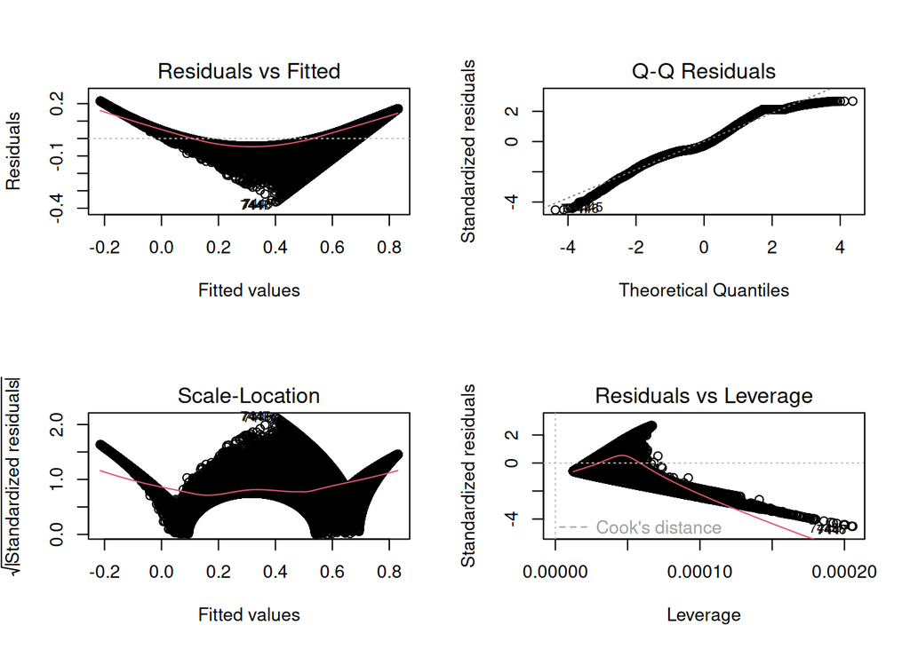

Diagnostic plots for the linear model predicting bb_area from bb_width and bb_height. Top-left: Residuals vs Fitted. Top-right: Normal Q-Q of residuals. Bottom-left: Scale-Location. Bottom-right: Residuals vs Leverage.

```r
# Fit the linear model: bb_area ~ bb_width + bb_height
lm_area <- lm(bb_area ~ bb_width + bb_height, data = df_present)

# Display the four diagnostic plots
par(mfrow = c(2, 2))
plot(lm_area)
```

```r
par(mfrow = c(1, 1))
```

**Interpretation of Diagnostic Plots:**

- **Residuals vs Fitted:** A horizontal red line with random scatter indicates good fit. A funnel shape indicates heteroscedasticity.
- **Normal Q-Q:** Points should follow the diagonal line if residuals are normally distributed.
- **Scale-Location:** A horizontal line with equally spread points confirms homoscedasticity.
- **Residuals vs Leverage:** Identifies influential data points (Cook’s distance > 0.5 is concerning).

## 9.5 Evaluation of Linear Regression with Selected Predictors

```r
# Fit an improved model using log-transformed variables
lm_log_area <- lm(log_bb_area ~ log_bb_width + log_bb_height, data = df_present)

# --- Coefficients table for Original Model ---
orig_coef <- as.data.frame(summary(lm_area)$coefficients)
orig_coef$Term <- rownames(orig_coef)
orig_coef <- orig_coef[, c("Term", "Estimate", "Std. Error", "t value", "Pr(>|t|)")]

kable(
  data.frame(
    Term      = orig_coef$Term,
    Estimate  = round(orig_coef$Estimate, 5),
    Std_Error = round(orig_coef$`Std. Error`, 5),
    T_Value   = round(orig_coef$`t value`, 3),
    P_Value   = formatC(orig_coef$`Pr(>|t|)`, format = "e", digits = 3)
  ),
  col.names = c("Term", "Estimate", "Std. Error", "t Value", "P-Value"),
  caption   = "Original Model Coefficients: bb_area ~ bb_width + bb_height"
) %>%
  kable_styling(bootstrap_options = c("striped", "hover", "bordered"),
                full_width = FALSE,
                font_size  = 13) %>%
  column_spec(1, bold = TRUE) %>%
  row_spec(0, background = "#4E79A7", color = "white")
```

Original Model Coefficients: bb_area ~ bb_width + bb_height

| Term | Estimate | Std. Error | t Value | P-Value |
| --- | --- | --- | --- | --- |
| (Intercept) | -0.22619 | 0.00067 | -338.632 | 0.000e+00 |
| bb_width | 0.61186 | 0.00116 | 526.420 | 0.000e+00 |
| bb_height | 0.44415 | 0.00121 | 367.973 | 0.000e+00 |

```r
# --- Coefficients table for Log-Transformed Model ---
log_coef <- as.data.frame(summary(lm_log_area)$coefficients)
log_coef$Term <- rownames(log_coef)
log_coef <- log_coef[, c("Term", "Estimate", "Std. Error", "t value", "Pr(>|t|)")]

kable(
  data.frame(
    Term      = log_coef$Term,
    Estimate  = round(log_coef$Estimate, 5),
    Std_Error = round(log_coef$`Std. Error`, 5),
    T_Value   = round(log_coef$`t value`, 3),
    P_Value   = formatC(log_coef$`Pr(>|t|)`, format = "e", digits = 3)
  ),
  col.names = c("Term", "Estimate", "Std. Error", "t Value", "P-Value"),
  caption   = "Log-Transformed Model Coefficients: log(bb_area) ~ log(bb_width) + log(bb_height)"
) %>%
  kable_styling(bootstrap_options = c("striped", "hover", "bordered"),
                full_width = FALSE,
                font_size  = 13) %>%
  column_spec(1, bold = TRUE) %>%
  row_spec(0, background = "#59A14F", color = "white")
```

Log-Transformed Model Coefficients: log(bb_area) ~ log(bb_width) + log(bb_height)

| Term | Estimate | Std. Error | t Value | P-Value |
| --- | --- | --- | --- | --- |
| (Intercept) | -0.19509 | 0.00051 | -383.846 | 0.000e+00 |
| log_bb_width | 0.64936 | 0.00118 | 550.771 | 0.000e+00 |
| log_bb_height | 0.48468 | 0.00126 | 383.267 | 0.000e+00 |

```r
# --- Model comparison table ---
model_comparison <- data.frame(
  Model         = c("Original", "Log-Transformed"),
  R_squared     = round(c(summary(lm_area)$r.squared,
                           summary(lm_log_area)$r.squared), 4),
  Adj_R_squared = round(c(summary(lm_area)$adj.r.squared,
                           summary(lm_log_area)$adj.r.squared), 4),
  RSE           = round(c(summary(lm_area)$sigma,
                           summary(lm_log_area)$sigma), 5),
  F_Statistic   = round(c(summary(lm_area)$fstatistic[1],
                           summary(lm_log_area)$fstatistic[1]), 2)
)

kable(model_comparison,
      col.names = c("Model", "R-Squared", "Adj. R-Squared",
                    "Residual Std. Error", "F-Statistic"),
      caption   = "Model Comparison: Original vs Log-Transformed") %>%
  kable_styling(bootstrap_options = c("striped", "hover", "bordered"),
                full_width = FALSE,
                font_size  = 13) %>%
  column_spec(1, bold = TRUE) %>%
  column_spec(2, bold = TRUE) %>%
  row_spec(0, background = "#343a40", color = "white") %>%
  row_spec(1, background = "#e8f4f8") %>%
  row_spec(2, background = "#d4edda")
```

Model Comparison: Original vs Log-Transformed

| Model | R-Squared | Adj. R-Squared | Residual Std. Error | F-Statistic |
| --- | --- | --- | --- | --- |
| Original | 0.9191 | 0.9191 | 0.08038 | 457015.4 |
| Log-Transformed | 0.9280 | 0.9280 | 0.05401 | 518872.0 |

**Interpretation:** Both models show highly significant predictors (p < 0.001). The original model coefficients table (blue header) shows the raw relationships, while the log-transformed model (green header) produces more normally distributed residuals. The comparison table at the bottom highlights the original model in blue and the log-transformed model in green — the log model’s lower Residual Standard Error confirms it is the better fit. R-squared is high in both models since `bb_area` is mathematically derived from the two predictors.

## 9.6 R-Squared Explanation

R-squared (R²) measures the **proportion of variance in the outcome variable** explained by the predictors. It ranges from 0 (model explains nothing) to 1 (model explains everything). An R² of 0.85 means the model explains 85% of the variability in the outcome. Here, R² is expected to be high because `bb_area` is literally computed from the two predictors.

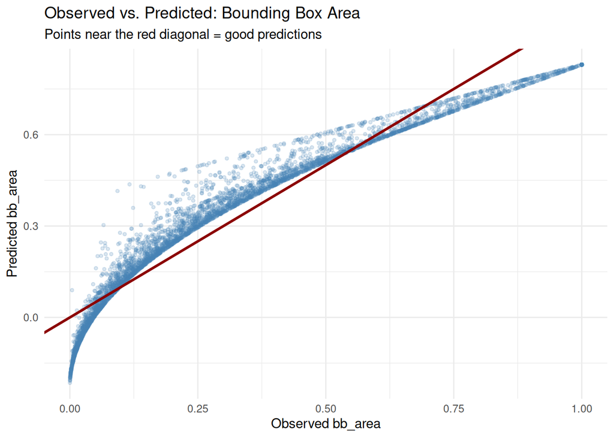

Observed vs. predicted bounding box area for a sample of 5,000 annotations. Points close to the red diagonal line indicate accurate predictions. Spread around the line reflects prediction error.

```r
ggplot(df_sample,
       aes(x = bb_area, y = predict(lm_area, newdata = df_sample))) +
  geom_point(alpha = 0.2, color = "steelblue", size = 1) +
  geom_abline(slope = 1, intercept = 0, color = "darkred", linewidth = 1) +
  labs(title = "Observed vs. Predicted: Bounding Box Area",
       subtitle = "Points near the red diagonal = good predictions",
       x = "Observed bb_area",
       y = "Predicted bb_area") +
  theme_minimal()
```

**Interpretation:** Points close to the diagonal reference line indicate that the model’s predictions match observed values well. Systematic deviations indicate model misfit, which may be addressed with transformations or additional predictors.

# 10. Summary and Conclusions

In this Part 2 project, we applied advanced EDA techniques to the YouTube-BoundingBoxes dataset:

**What did we find vs. what we expected?** Our hypothesis was confirmed bounding box width and height are positively correlated, and bounding box area can be effectively predicted from these two dimensions.

**Limitation:** The dataset has significant class imbalance, so results may be disproportionately influenced by the most common classes like *person*. Future work could fit separate models per class for more specific insights.